# WDI 2022 Report

Author

Jinhao Tian

Published

October 4, 2025

# Data Loading

In this section, I load the World Development Indicators dataset for 2022 (Bank 2022).

```python
import pandas as pd

# Load the dataset
df = pd.read_csv("wdi.csv")

# Show a small preview (as a figure-like output)
df.head()
```

|  | country | inflation_rate | exports_gdp_share | gdp_growth_rate | gdp_per_capita | adult_literacy_rate | primary_school_enrolment_rate | education_expenditure_gdp_share | measles_immunisation_rate | health_expenditure_gdp_share | income_inequality | unemployment_rate | life_expectancy | total_population |
| --- | --- | --- | --- | --- | --- | --- | --- | --- | --- | --- | --- | --- | --- | --- |
| 0 | Afghanistan | NaN | 18.380042 | -6.240172 | 352.603733 | NaN | NaN | NaN | 68.0 | NaN | NaN | 14.100 | 62.879 | 41128771.0 |
| 1 | Albania | 6.725203 | 37.395422 | 4.856402 | 6810.114041 | 98.5 | 95.606712 | 2.74931 | 86.0 | NaN | NaN | 11.588 | 76.833 | 2777689.0 |
| 2 | Algeria | 9.265516 | 31.446856 | 3.600000 | 5023.252932 | NaN | 108.343933 | NaN | 79.0 | NaN | NaN | 12.437 | 77.129 | 44903225.0 |
| 3 | American Samoa | NaN | 46.957520 | 1.735016 | 19673.390102 | NaN | NaN | NaN | NaN | NaN | NaN | NaN | NaN | 44273.0 |
| 4 | Andorra | NaN | NaN | 9.563798 | 42350.697069 | NaN | 90.147346 | 2.66623 | 98.0 | NaN | NaN | NaN | NaN | 79824.0 |

Figure 1: Preview of the WDI sample (first 5 rows). Source: [World Bank WDI](https://databank.worldbank.org/source/world-development-indicators).

# Exploratory Data Analysis (EDA)

This section explores **GDP per capita**, **Life expectancy**, and **Inflation (CPI, annual %)** for 2022.

## 1) GDP per capita (levels and distribution)

I examine summary statistics, missingness, and the distribution in both raw and log scales.

```python
# quick summary in text output
import numpy as np
print("Missing values (gdp_per_capita):", df["gdp_per_capita"].isna().sum())
print(df["gdp_per_capita"].describe())
```

```
Missing values (gdp_per_capita): 14
count       203.000000
mean      20345.707649
std       31308.942225
min         259.025031
25%        2570.563284
50%        7587.588173
75%       25982.630050
max      240862.182448
Name: gdp_per_capita, dtype: float64
```

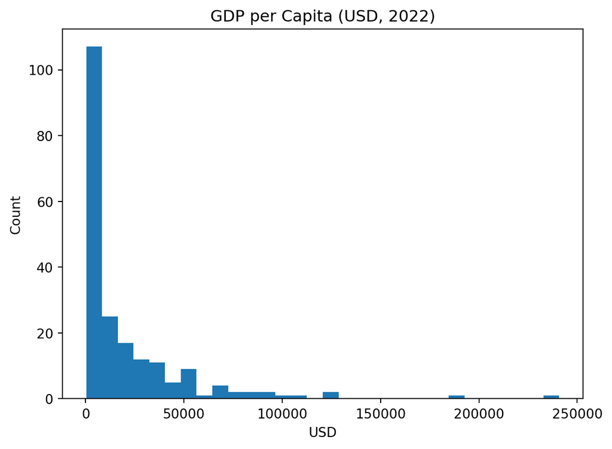

Figure 2: Distribution of GDP per capita (USD, 2022). Source: [World Bank WDI](https://databank.worldbank.org/source/world-development-indicators).

```python
import matplotlib.pyplot as plt
x = df["gdp_per_capita"].dropna()
plt.figure()
plt.hist(x, bins=30)
plt.title("GDP per Capita (USD, 2022)")
plt.xlabel("USD")
plt.ylabel("Count")
plt.show()
```

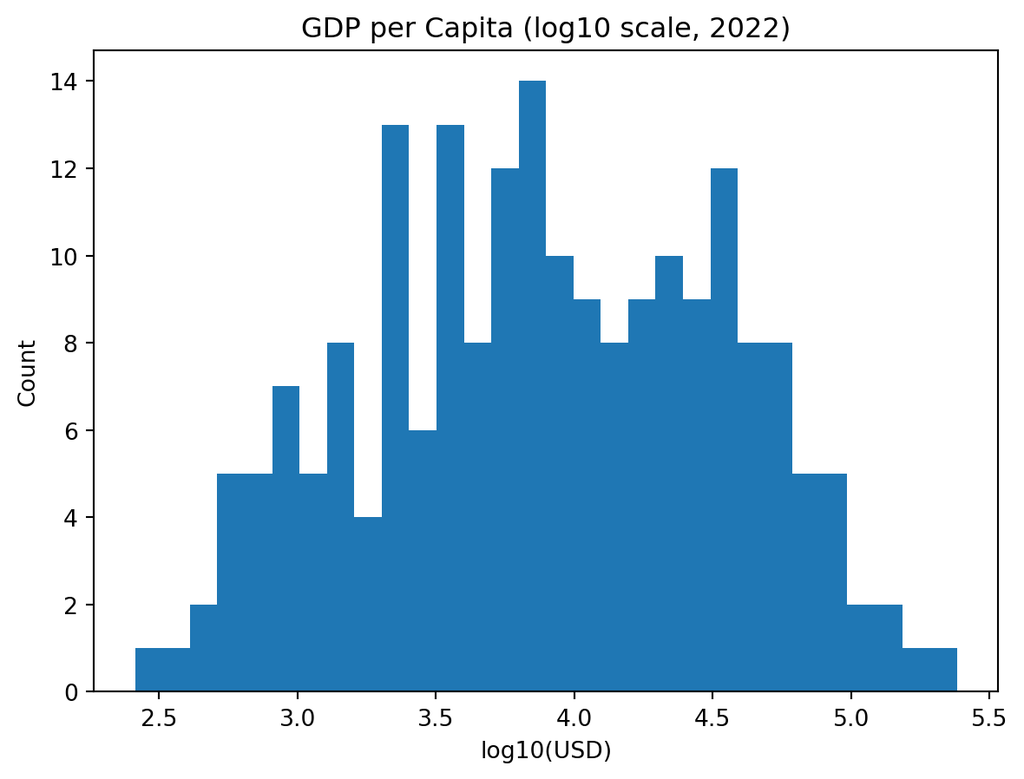

Figure 3: Distribution of GDP per capita on log₁₀ scale (2022). Source: [World Bank WDI](https://databank.worldbank.org/source/world-development-indicators).

```python
import numpy as np
import matplotlib.pyplot as plt
x = df["gdp_per_capita"].dropna()
plt.figure()
plt.hist(np.log10(x[x>0]), bins=30)
plt.title("GDP per Capita (log10 scale, 2022)")
plt.xlabel("log10(USD)")
plt.ylabel("Count")
plt.show()
```

**Summary — GDP per capita (2022)**  
- The distribution is **highly right-skewed**: most countries cluster below ~$20k, with a **long tail** of high-income economies.  
- On a **log scale**, the distribution looks much closer to symmetric (roughly log-normal), which is typical for income variables.  
- Interpretation: comparing countries on the **log** of GDP per capita (rather than raw USD) is more informative and reduces the influence of outliers.

## 2) Life expectancy (levels and relation to income)

I inspect the distribution of life expectancy and its relationship with income (diminishing returns expected), a pattern first described by Preston (Preston 1975).

```python
# brief summary
print("Missing values (life_expectancy):", df["life_expectancy"].isna().sum())
print(df["life_expectancy"].describe())
```

```
Missing values (life_expectancy): 8
count    209.000000
mean      72.416519
std        7.713322
min       52.997000
25%       66.782000
50%       73.514634
75%       78.475000
max       85.377000
Name: life_expectancy, dtype: float64
```

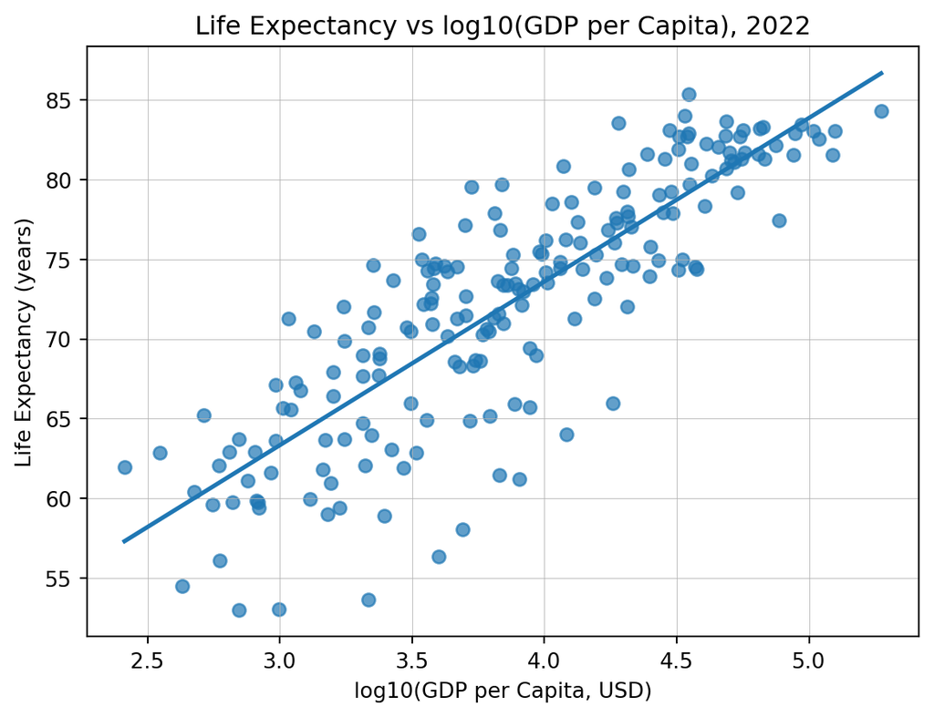

Figure 4: Life expectancy vs log₁₀(GDP per capita), 2022. Source: [World Bank WDI](https://databank.worldbank.org/source/world-development-indicators).

```
Correlation (life expectancy vs log10 GDP per capita): 0.841
```

```python
import numpy as np
import matplotlib.pyplot as plt


gdp_le = df[["gdp_per_capita","life_expectancy"]].dropna().copy()
x = np.log10(gdp_le["gdp_per_capita"].values)
y = gdp_le["life_expectancy"].values

m, b = np.polyfit(x, y, 1)
plt.figure()
plt.scatter(x, y, alpha=0.7)
plt.plot(np.sort(x), m*np.sort(x)+b, linewidth=2)
plt.title("Life Expectancy vs log10(GDP per Capita), 2022")
plt.xlabel("log10(GDP per Capita, USD)")
plt.ylabel("Life Expectancy (years)")
plt.grid(True, linewidth=0.3)
plt.show()

print(f"Correlation (life expectancy vs log10 GDP per capita): {np.corrcoef(x,y)[0,1]:.3f}")
```

**Summary — Life expectancy vs GDP per capita**  
- There is a **strong positive association**: the correlation with **log₁₀(GDP per capita)** is about **0.84** in the output.  
- The **slope flattens at higher incomes**, consistent with **diminishing returns** (gains in life expectancy are large at low incomes and smaller at high incomes), this finding aligns with macroeconomic theories discussed by Mankiw (Mankiw 2019). .  
- Takeaway: income is a powerful predictor of population health, especially among lower-income countries. —

## 3) Inflation (levels and relation to growth)

I examine inflation levels and its same-year association with GDP growth.

```
Missing values (inflation_rate): 48
count    169.000000
mean      12.493936
std       19.682433
min       -6.687321
25%        5.518129
50%        7.967574
75%       11.665567
max      171.205491
Name: inflation_rate, dtype: float64
```

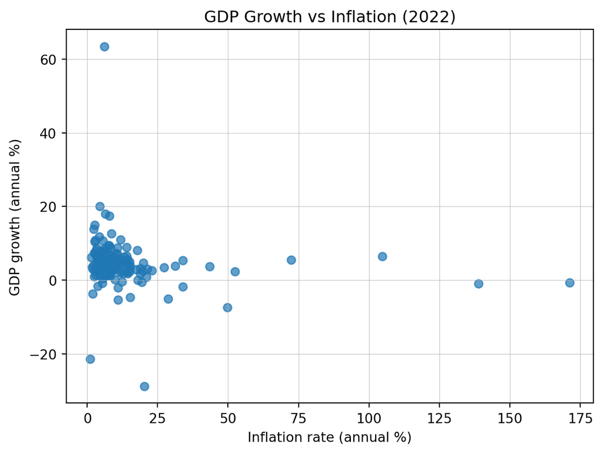

```
Correlation (GDP growth vs inflation): -0.140
```

```python
# brief summary
print("Missing values (inflation_rate):", df["inflation_rate"].isna().sum())
print(df["inflation_rate"].describe())

#| label: fig-growth-vs-infl
#| fig-cap: "GDP growth vs inflation, 2022. Source: [World Bank WDI](https://databank.worldbank.org/source/world-development-indicators)."
import numpy as np
import matplotlib.pyplot as plt

if "gdp_growth_rate" in df.columns:
    infl_growth = df[["inflation_rate","gdp_growth_rate"]].dropna()
    plt.figure()
    plt.scatter(infl_growth["inflation_rate"], infl_growth["gdp_growth_rate"], alpha=0.7)
    plt.title("GDP Growth vs Inflation (2022)")
    plt.xlabel("Inflation rate (annual %)")
    plt.ylabel("GDP growth (annual %)")
    plt.grid(True, linewidth=0.3)
    plt.show()

    r = np.corrcoef(infl_growth["inflation_rate"], infl_growth["gdp_growth_rate"])[0,1]
    print(f"Correlation (GDP growth vs inflation): {r:.3f}")
else:
    print("Column 'gdp_growth_rate' not found in the dataset.")
```

**Summary — GDP growth vs inflation (2022)**  
- The cross-section shows a **weak negative correlation** (≈ **−0.14**), and the scatter is **very noisy**.  
- Several **extreme-inflation outliers** pull the pattern around; excluding them would likely make the relationship even weaker.  
- Same-year cross-sectional comparisons don’t identify causality—growth and inflation dynamics are **time-dependent**; panel/time-series analysis would be more appropriate.

## Visualisations

### Top GDP per Capita (Bar Chart)

As shown in (Figure 5), high-income economies dominate the upper tail of GDP per capita in 2022.

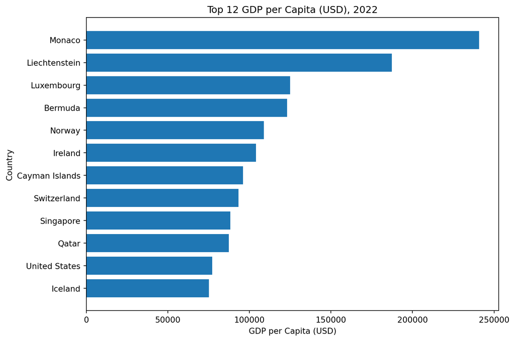

Figure 5: Top 12 countries by GDP per capita (2022). Source: [World Bank WDI](https://databank.worldbank.org/source/world-development-indicators).

```python
import matplotlib.pyplot as plt

gdp_top = (
    df[["country", "gdp_per_capita"]]
    .dropna()
    .sort_values("gdp_per_capita", ascending=False)
    .head(12)
    .iloc[::-1]
)

plt.figure(figsize=(9,6))
plt.barh(gdp_top["country"], gdp_top["gdp_per_capita"])
plt.title("Top 12 GDP per Capita (USD), 2022")
plt.xlabel("GDP per Capita (USD)")
plt.ylabel("Country")
plt.tight_layout()
plt.show()
```

### Life Expectancy vs Income (Scatter)

In (Figure 6), life expectancy rises with income, with diminishing returns at high income.

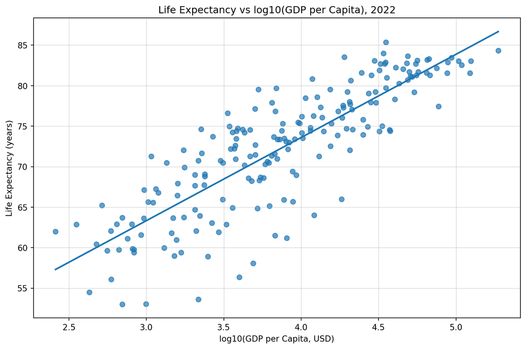

Figure 6: Life expectancy vs. log₁₀(GDP per capita), 2022. Source: [World Development Indicators — World Bank](https://databank.worldbank.org/source/world-development-indicators).

### Key Statistics Table

Table Table 1 summarizes the indicators used in the analysis and supports the distributional findings in Figure 2 and the relationship in Figure 4.

```python
import pandas as pd
import numpy as np

indicators = {
    "gdp_per_capita": "GDP per capita (USD)",
    "life_expectancy": "Life expectancy (years)",
    "inflation_rate": "Inflation rate (%)",
}

use_cols = [c for c in indicators if c in df.columns]
desc = (
    df[use_cols]
    .describe(percentiles=[], include="all")
    .loc[["count","mean","50%","std","min","max"]]
    .rename(index={"50%":"median"})
    .T
)

def fmt_row(name, row):
    row = row.copy()
    if name == "gdp_per_capita":
        for c in ["mean","median","std","min","max"]:
            row[c] = f"{row[c]:,.0f}"
    elif name in ["life_expectancy"]:
        for c in ["mean","median","std","min","max"]:
            row[c] = f"{row[c]:.1f}"
    else:  # inflation_rate or other %
        for c in ["mean","median","std","min","max"]:
            row[c] = f"{row[c]:.2f}"
    row["count"] = int(row["count"])
    return row

display_df = pd.DataFrame(
    [fmt_row(name, desc.loc[name]) for name in desc.index],
    index=[indicators[name] for name in desc.index]
)[["count","mean","median","std","min","max"]]

display_df
```

Table 1: Key statistics for selected indicators (2022). Source: [World Bank WDI](https://databank.worldbank.org/source/world-development-indicators).

|  | count | mean | median | std | min | max |
| --- | --- | --- | --- | --- | --- | --- |
| GDP per capita (USD) | 203 | 20,346 | 7,588 | 31,309 | 259 | 240,862 |
| Life expectancy (years) | 209 | 72.4 | 73.5 | 7.7 | 53.0 | 85.4 |
| Inflation rate (%) | 169 | 12.49 | 7.97 | 19.68 | -6.69 | 171.21 |

## References

Bank, World. 2022. “World Development Indicators 2022.” https://databank.worldbank.org/source/world-development-indicators.

Mankiw, N. Gregory. 2019. *Principles of Economics*. 9th ed. Cengage Learning.

Preston, Samuel H. 1975. “The Changing Relation Between Mortality and Level of Economic Development.” *Population Studies* 29 (2): 231–48. https://doi.org/10.1080/00324728.1975.10410201.